# DA5020.A3.Yicheng.Zhang

YICHENG ZHANG

2022-09-20

## Question 2

```r
# Please make sure the file is in your working directory before you test this script!!
# This is the way I read the table into a dataframe

tripdata_df <- read.csv("2018_Green_Taxi_Trip_Data.csv")

# Here is the dimension of this dataframe

dim(tripdata_df)
```

```
## [1] 1048575      19
```

```r
# Here is the frequency of NA value in each column of this dataframe

colSums(is.na(tripdata_df))
```

```
##              VendorID  lpep_pickup_datetime lpep_dropoff_datetime
##                     0                     0                     0
##    store_and_fwd_flag            RatecodeID          PULocationID
##                     0                     0                     0
##          DOLocationID       passenger_count         trip_distance
##                     0                     0                     0
##           fare_amount                 extra               mta_tax
##                     0                     0                     0
##            tip_amount          tolls_amount             ehail_fee
##                     0                     0               1048575
## improvement_surcharge          total_amount          payment_type
##                     0                     0                     0
##             trip_type
##                     3
```

From the result above, we can see that the dimension of the dataset is 1048575 rows and 19 columns; there are 3 missing value in the `trip_type` and 1048575 missing value in the `ehail_fee`.

## Question 3

There are at least 4 things I think might be invalid in this dataset:

### Invalid no.1:

```r
# The ehail_fee should be a logic character but It has too many NA value which we might think it is invalid
# The variable ehail_fee has too many missing value:

sum(is.na(tripdata_df$ehail_fee))
```

```
## [1] 1048575
```

From the output here we can see that the variable `ehail_free` has all missing value and this could be a invalid sign. Because we don’t want to have a column of logic character with none sense value in our dataset.

### Invalid no.2:

```r
# The total_amount and fare_amount payment should be number instead of character:

str(tripdata_df$total_amount)
```

```
##  chr [1:1048575] "7.3" "15.8" "11.3" "-4.3" "4.3" "22.3" "9.8" "18.96" ...
```

```r
str(tripdata_df$fare_amount)
```

```
##  chr [1:1048575] "6" "14.5" "10" "-3" "3" "21" "8.5" "14.5" "10" "7.5" ...
```

The total amount and fare amount should be number. However, we have here the `total_amount` and `fare_amount` as character which mean both of them have invalid data types.

### Invalid no.3:

```r
# The trip_type should be factor:

str(tripdata_df$trip_type)
```

```
##  int [1:1048575] 1 1 1 1 1 1 1 1 1 1 ...
```

By doing through the data dictionary, we know that the `trip_type`should be a categorical variable which means it is a factor, however, here the data set store the variable as integer which is invalid.

### Invalid no.4:

```r
# The store_and_fwd_flag should be logic character but not the chr:

str(tripdata_df$store_and_fwd_flag)
```

```
##  chr [1:1048575] "N" "N" "N" "N" "N" "N" "N" "N" "N" "N" "N" "N" "N" "N" ...
```

Since the `store_and_fwd_flag` suppose to record if the record was held in the vehicle, so it should be a logic character with yes or no (Y/N) instead of a character. This is a invalid datatype.

Now we want to change some of the variables into the factor:

```r
tripdata_df<-tripdata_df %>%
  mutate(across(c(trip_type,RatecodeID,VendorID),as.factor))

# double check with the stracture, they should be factor now;

str(tripdata_df)
```

```
## 'data.frame':    1048575 obs. of  19 variables:
##  $ VendorID             : Factor w/ 2 levels "1","2": 2 2 2 2 2 2 2 2 2 2 ...
##  $ lpep_pickup_datetime : chr  "1/1/2018 0:18" "1/1/2018 0:30" "1/1/2018 0:07" "1/1/2018 0:32" ...
##  $ lpep_dropoff_datetime: chr  "1/1/2018 0:24" "1/1/2018 0:46" "1/1/2018 0:19" "1/1/2018 0:33" ...
##  $ store_and_fwd_flag   : chr  "N" "N" "N" "N" ...
##  $ RatecodeID           : Factor w/ 7 levels "1","2","3","4",..: 1 1 1 1 1 1 1 1 1 1 ...
##  $ PULocationID         : int  236 43 74 255 255 255 189 189 129 226 ...
##  $ DOLocationID         : int  236 42 152 255 255 161 65 225 82 7 ...
##  $ passenger_count      : int  5 5 1 1 1 1 5 5 1 1 ...
##  $ trip_distance        : num  0.7 3.5 2.14 0.03 0.03 5.63 1.71 3.45 1.61 1.87 ...
##  $ fare_amount          : chr  "6" "14.5" "10" "-3" ...
##  $ extra                : num  0.5 0.5 0.5 -0.5 0.5 0.5 0.5 0.5 0.5 0.5 ...
##  $ mta_tax              : num  0.5 0.5 0.5 -0.5 0.5 0.5 0.5 0.5 0.5 0.5 ...
##  $ tip_amount           : num  0 0 0 0 0 0 0 3.16 0 0 ...
##  $ tolls_amount         : num  0 0 0 0 0 0 0 0 0 0 ...
##  $ ehail_fee            : logi  NA NA NA NA NA NA ...
##  $ improvement_surcharge: num  0.3 0.3 0.3 -0.3 0.3 0.3 0.3 0.3 0.3 0.3 ...
##  $ total_amount         : chr  "7.3" "15.8" "11.3" "-4.3" ...
##  $ payment_type         : int  2 2 2 3 2 2 2 1 2 2 ...
##  $ trip_type            : Factor w/ 2 levels "1","2": 1 1 1 1 1 1 1 1 1 1 ...
```

By going through the data dictionary we know `trip_type` ,`RatecodeID` ,`VendorID` are categorical variables which we want to transform them into factors in this data set.

## Question 4

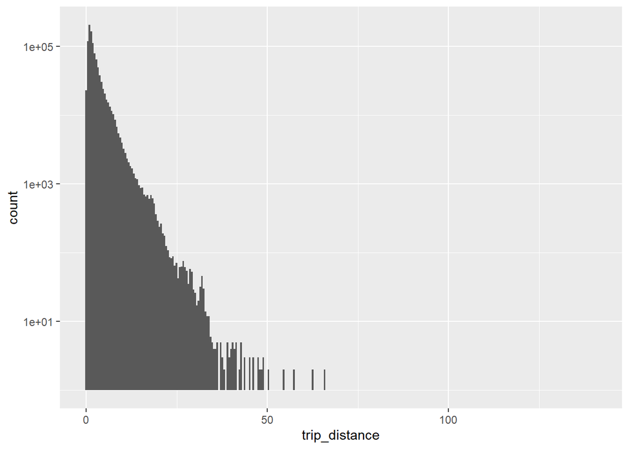

```r
# We draw the plot with the log scale to the y axis:

ggplot(data=tripdata_df, aes(trip_distance)) +
  geom_histogram(bins=300)+
  scale_y_log10()
```

From the output of the histogram we can see the result is super skew and it indicates it is a skewed right distribution. In this case, it might because the lower bound of the data. So, if the bottom limits of the `trip_distance` is exceedingly low in comparison to the rest of the data then the result of distribution will go right skewed, and we can assume the lowest data here is approaching to 0. In short, there are outliers in the `trip_distance` variables need to be removed if we want to further analyze this data set.

## Question 5

```r
# Here we first find outliers for the tip amount:

outlier_tip_amount<-tripdata_df %>% filter(tip_amount>mean(tip_amount)+3*sd(tip_amount)|tip_amount < mean(tip_amount) - 3*sd(tip_amount))
str(outlier_tip_amount)
```

```
## 'data.frame':    14444 obs. of  19 variables:
##  $ VendorID             : Factor w/ 2 levels "1","2": 2 2 2 2 2 2 1 1 1 2 ...
##  $ lpep_pickup_datetime : chr  "1/1/2018 0:53" "1/1/2018 1:01" "1/1/2018 0:34" "1/1/2018 0:52" ...
##  $ lpep_dropoff_datetime: chr  "1/1/2018 1:26" "1/1/2018 1:41" "1/1/2018 0:53" "1/1/2018 1:17" ...
##  $ store_and_fwd_flag   : chr  "N" "N" "N" "N" ...
##  $ RatecodeID           : Factor w/ 7 levels "1","2","3","4",..: 1 1 1 1 5 1 1 1 1 1 ...
##  $ PULocationID         : int  97 228 223 7 7 255 40 61 255 255 ...
##  $ DOLocationID         : int  74 127 40 100 7 95 90 25 68 244 ...
##  $ passenger_count      : int  1 1 5 5 6 2 1 1 1 1 ...
##  $ trip_distance        : num  11.79 18.54 11.47 7.78 0 ...
##  $ fare_amount          : chr  "36" "53" "32" "27.5" ...
##  $ extra                : num  0.5 0.5 0.5 0.5 0 0.5 0.5 0.5 0.5 0.5 ...
##  $ mta_tax              : num  0.5 0.5 0.5 0.5 0 0.5 0.5 0.5 0.5 0.5 ...
##  $ tip_amount           : num  7.46 8.14 9.99 6.91 10 7.16 6.8 9 15 8.06 ...
##  $ tolls_amount         : num  0 0 0 5.76 0 0 0 0 0 0 ...
##  $ ehail_fee            : logi  NA NA NA NA NA NA ...
##  $ improvement_surcharge: num  0.3 0.3 0.3 0.3 0 0.3 0.3 0.3 0.3 0.3 ...
##  $ total_amount         : chr  "46.71" "64.39" "43.29" "41.47" ...
##  $ payment_type         : int  1 1 1 1 1 1 1 1 1 1 ...
##  $ trip_type            : Factor w/ 2 levels "1","2": 1 1 1 1 2 1 1 1 1 1 ...
```

If we consider those observations with `tip_amount` 3 standard deviation from the mean as the outlier, then there are 14444 observations are outliers in this case. From the output above we can see that 14444 outliers rgarding to `tip_amount` are found.

```r
# Now we can evaluate the outliers for the trip distance:

outlier_trip_distance<-tripdata_df %>% filter(trip_distance>mean(trip_distance)+3*sd(trip_distance)|trip_distance < mean(trip_distance) - 3*sd(trip_distance))
str(outlier_trip_distance)
```

```
## 'data.frame':    20953 obs. of  19 variables:
##  $ VendorID             : Factor w/ 2 levels "1","2": 2 2 2 2 2 2 2 2 2 2 ...
##  $ lpep_pickup_datetime : chr  "1/1/2018 0:53" "1/1/2018 1:01" "1/1/2018 0:52" "1/1/2018 0:45" ...
##  $ lpep_dropoff_datetime: chr  "1/1/2018 1:26" "1/1/2018 1:41" "1/1/2018 1:55" "1/1/2018 1:33" ...
##  $ store_and_fwd_flag   : chr  "N" "N" "N" "N" ...
##  $ RatecodeID           : Factor w/ 7 levels "1","2","3","4",..: 1 1 1 1 1 1 1 1 1 1 ...
##  $ PULocationID         : int  97 228 97 36 49 223 265 244 255 25 ...
##  $ DOLocationID         : int  74 127 116 238 173 40 196 265 95 127 ...
##  $ passenger_count      : int  1 1 1 1 1 5 1 2 2 1 ...
##  $ trip_distance        : num  11.8 18.5 14.9 16 12.9 ...
##  $ fare_amount          : chr  "36" "53" "51.5" "50.5" ...
##  $ extra                : num  0.5 0.5 0.5 0.5 0.5 0.5 0.5 0.5 0.5 0.5 ...
##  $ mta_tax              : num  0.5 0.5 0.5 0.5 0.5 0.5 0.5 0.5 0.5 0.5 ...
##  $ tip_amount           : num  7.46 8.14 0 0 0 9.99 0 5 7.16 0 ...
##  $ tolls_amount         : num  0 0 0 0 0 0 0 0 0 0 ...
##  $ ehail_fee            : logi  NA NA NA NA NA NA ...
##  $ improvement_surcharge: num  0.3 0.3 0.3 0.3 0.3 0.3 0.3 0.3 0.3 0.3 ...
##  $ total_amount         : chr  "46.71" "64.39" "52.8" "51.8" ...
##  $ payment_type         : int  1 1 1 1 2 1 2 1 1 2 ...
##  $ trip_type            : Factor w/ 2 levels "1","2": 1 1 1 1 1 1 1 1 1 1 ...
```

If we consider those observations with `trip_distance` 3 standard deviation from the mean as the outlier, then there are 20953 observations are outliers in this case. From the output above we can see that 20953 outliers regarding to `trip_amount` are found.

```r
# Now we want to remove outliers regarding to the tip amount and create a new data set called none_outliers:

none_outliers<-tripdata_df %>% filter(tip_amount<=mean(tip_amount)+3*sd(tip_amount)&tip_amount>=mean(tip_amount)-3*sd(tip_amount))

# New dataset without the tip_amount outlier

dim(none_outliers)
```

```
## [1] 1034131      19
```

Here we removed the outliers of `tip_amount` and we have 1034131 observations left in this case.

## Question 6

Sincer there is no specific standardized definition about outliers in this question. We use 2 methods to remove the outliers here:

### Method 1:

We use the quantile() to get the first and third quartiles. Furthermore, we compute first quantile - 1.5*IQR to get the lower limit for outliers, and similarly, we compute third quantile + 1.5*IQR to get the upper bound.

```r
data<-tripdata_df[,1:19]

q <- quantile(data$trip_distance, probs=c(.25, .75), na.rm = FALSE)
Interq <- IQR(data$trip_distance)

Lower_boundary <- q[1] - 1.5*Interq
Upper_boundary <- q[2] + 1.5*Interq

# remove outliers:

data_no_outlier3 <- subset(data, data$trip_distance > Lower_boundary & data$trip_distance < Upper_boundary)

dim(data_no_outlier3)
```

```
## [1] 965712     19
```

From the result above we can see that now there are only 965712 obs left after we remove the outliers of `trip_distance`. Now we use `group by` to attach each of obs to the `payment_type`:

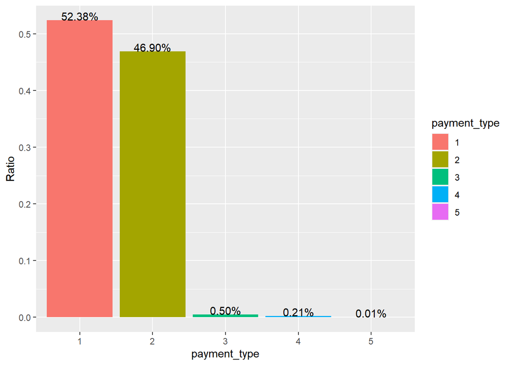

```r
data_no_outlier4 <- data_no_outlier3 %>%
    group_by(payment_type) %>%
    summarise(Count = n()) %>%
    mutate( payment_type = factor(payment_type),
            Ratio = Count / sum(Count), # we compute the frequency here
            label = percent(Ratio))

visual_result1 <- ggplot(data_no_outlier4, aes(x=payment_type,y=Ratio,label=label,fill=payment_type)) +
    geom_bar(stat='identity') +
    geom_text(vjust=0)

# check the result:

visual_result1
```

### Method 2:

Here we refer to the previous question, consider outliers are 3 standard deviations from the mean:

```r
# We need to first remove the outliers

none_outliers2<-tripdata_df %>% filter(trip_distance<=mean(trip_distance)+3*sd(trip_distance)&trip_distance >= mean(trip_distance) - 3*sd(trip_distance))%>%
  # Now we want to mutate payment_type to a factor
  mutate(payment_type=as.factor(payment_type))

# check out how many obs left after we remove the outliers:

dim(none_outliers2)
```

```
## [1] 1027622      19
```

From the output above we can see that, if we consider outliers as 3 standard deviations from the mean, then this time we will have 1027622 obs left after we remove the outliers.

Now let’s visualize the result of this approach:

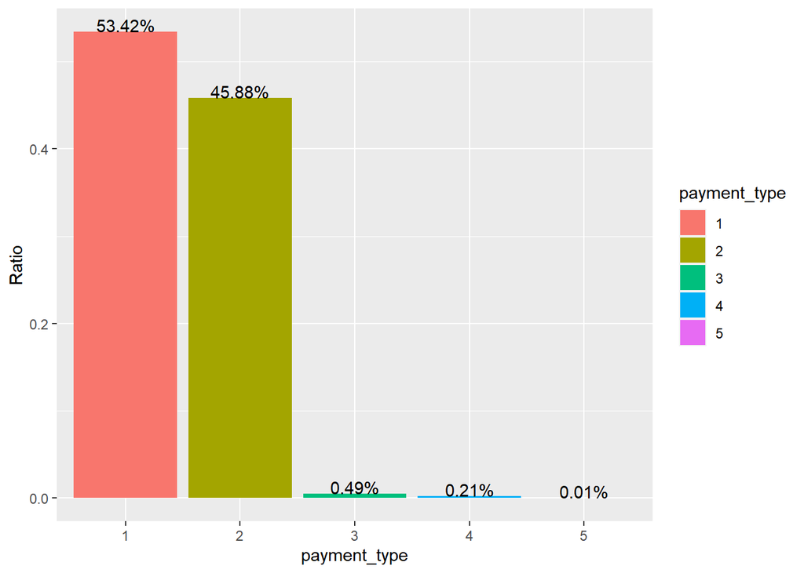

```r
# We first group by the payment_method:

tableQ6 <- none_outliers2 %>%
  group_by(payment_type) %>%
  summarise(Count = n()) %>%
  mutate( payment_type = factor(payment_type),
          Ratio = Count / sum(Count), # we compute the frequency here
          label = percent(Ratio))


# NOw we do the visualization in a bar chart view:

visual_result2 <- ggplot(tableQ6, aes(x=payment_type,y=Ratio,label=label,fill=payment_type)) +
  geom_bar(stat='identity') +
  geom_text(vjust=0)

# check visual result:

visual_result2
```

From the output above, still, more than 99% of people will choose to pay in cash and credit card. This time only 0.49% lucky passenger will have chance for the no charge, 0.21% passengers might have dispute with drivers, and 0.01% of the payment method is unknown. No voided trip exist in this data set. The result of this method is pretty much same as the last one.

Now, we can have a conclusion that by using both standards to define outliers, after we remove outliers, most people will choose to pay in cash and credit card. Around 0.5% people will have no charge. Around 0.21% people may dispute and 0.01% people pay in unknown way. Both of them have no voided trip occur.

## Question 7

In general, we have two common ways to deal with missing value in a data set. First is delete the missing value. Before we do that, We want to know the general situation about missing data in a dataset. For this assignment we use the taxi data and we can have a look about how many missing value exist in this dataset by:

```r
# Here is the number of NA value in each column of this dataframe
colSums(is.na(tripdata_df))
```

```
##              VendorID  lpep_pickup_datetime lpep_dropoff_datetime
##                     0                     0                     0
##    store_and_fwd_flag            RatecodeID          PULocationID
##                     0                     0                     0
##          DOLocationID       passenger_count         trip_distance
##                     0                     0                     0
##           fare_amount                 extra               mta_tax
##                     0                     0                     0
##            tip_amount          tolls_amount             ehail_fee
##                     0                     0               1048575
## improvement_surcharge          total_amount          payment_type
##                     0                     0                     0
##             trip_type
##                     3
```

From her we can see that only two variables has missing value in this dataset: `trip_type` and `ehail_fee`. For the `ehail_fee` we have all missing value, so we will choose to remove the missing value in this case when we have a variable with more than 70% of the missing value it will only have negative impact to our analysis and we want to just rule them out:

```r
tripdata_dfQ7<-tripdata_df %>% select(-ehail_fee)
str(tripdata_dfQ7)
```

```
## 'data.frame':    1048575 obs. of  18 variables:
##  $ VendorID             : Factor w/ 2 levels "1","2": 2 2 2 2 2 2 2 2 2 2 ...
##  $ lpep_pickup_datetime : chr  "1/1/2018 0:18" "1/1/2018 0:30" "1/1/2018 0:07" "1/1/2018 0:32" ...
##  $ lpep_dropoff_datetime: chr  "1/1/2018 0:24" "1/1/2018 0:46" "1/1/2018 0:19" "1/1/2018 0:33" ...
##  $ store_and_fwd_flag   : chr  "N" "N" "N" "N" ...
##  $ RatecodeID           : Factor w/ 7 levels "1","2","3","4",..: 1 1 1 1 1 1 1 1 1 1 ...
##  $ PULocationID         : int  236 43 74 255 255 255 189 189 129 226 ...
##  $ DOLocationID         : int  236 42 152 255 255 161 65 225 82 7 ...
##  $ passenger_count      : int  5 5 1 1 1 1 5 5 1 1 ...
##  $ trip_distance        : num  0.7 3.5 2.14 0.03 0.03 5.63 1.71 3.45 1.61 1.87 ...
##  $ fare_amount          : chr  "6" "14.5" "10" "-3" ...
##  $ extra                : num  0.5 0.5 0.5 -0.5 0.5 0.5 0.5 0.5 0.5 0.5 ...
##  $ mta_tax              : num  0.5 0.5 0.5 -0.5 0.5 0.5 0.5 0.5 0.5 0.5 ...
##  $ tip_amount           : num  0 0 0 0 0 0 0 3.16 0 0 ...
##  $ tolls_amount         : num  0 0 0 0 0 0 0 0 0 0 ...
##  $ improvement_surcharge: num  0.3 0.3 0.3 -0.3 0.3 0.3 0.3 0.3 0.3 0.3 ...
##  $ total_amount         : chr  "7.3" "15.8" "11.3" "-4.3" ...
##  $ payment_type         : int  2 2 2 3 2 2 2 1 2 2 ...
##  $ trip_type            : Factor w/ 2 levels "1","2": 1 1 1 1 1 1 1 1 1 1 ...
```

Now we can see that the entire `ehail_fee` are removed due to too many empty value.

Then for the second method we can deal with the missing value data is the imputation, which means we can try to assume the value of the missing data or randomly assign them certain values according to the overall situation of the dataset. Since we don’t want to bring our bias into the data we only apply this method when the missing value is few (<10%).Here the variable `trip_type` has only 3 missing value which we can definitely apply imputation here:

```r
# The R will randomly assign 1 or 2 to the NA value of this dataset

tripdata_dfQ7%>%filter(is.na(trip_type))
```

```
##   VendorID lpep_pickup_datetime lpep_dropoff_datetime store_and_fwd_flag
## 1        1       1/5/2018 10:14        1/5/2018 10:14                  Y
## 2        1        1/8/2018 7:19         1/8/2018 7:19                  Y
## 3        1      1/11/2018 14:06       1/11/2018 14:06                  N
##   RatecodeID PULocationID DOLocationID passenger_count trip_distance
## 1         99            7          264               0             0
## 2         99          179          264               0             0
## 3         99          264          264               0             0
##   fare_amount extra mta_tax tip_amount tolls_amount improvement_surcharge
## 1        9.35     0     0.0          0            0                   0.0
## 2        5.75     0     0.0          0            0                   0.0
## 3          35     0     0.5          0            0                   0.3
##   total_amount payment_type trip_type
## 1         9.35            3      <NA>
## 2         5.75            3      <NA>
## 3         35.8            1      <NA>
```

These 3 observations have missing value for the `trip_type` variable.

Now we impute them:

```r
tripdata_dfQ7$trip_type[is.na(tripdata_dfQ7$trip_type)]<- c(1,2)

# change it to factor :
tripdata_dfQ7<-tripdata_dfQ7%>%mutate(factor(trip_type))

sum(is.na(tripdata_dfQ7$trip_type))
```

```
## [1] 0
```

Now, all the missing values in this data set have been properly tackled.